# Cecilia’s Lab Project 1

## Introduction & Data Summary

Below is my work and write up for Project 1 of STAT 563 fall 2025.

Assignment goal: to apply MLE and IC to identify the most appropriate PDF to a simulated data and a given data set. The simulated data was given by Dr. Bozdogan and is found in the repo. The real-world data pertains to my graduate research and is not publicly available since it’s property of Oak Ridge National Laboratory. Therefore, I will not be attaching the dataset in the repo, but all code performed on it will be displayed on the R Notebook file available in the repo.

Disclaimer: I used assistance from ChatGPT to develop the code.

## Simulated Dataset

### Phase 1. Data Acquisition and Preparation

#### 1.1. Data Selection

The simulated data is given in Raw_Project_data.xlsx.

Set working directory to the repo and uplaod the simulated dataset:

```r
setwd("C:/Users/q4q/repos/STAT_563_Project_1")
# load package (must be installed first)
library(readxl)
Raw_Project_Data <- read_excel("STAT 563 LAB PROJECT#1 FALL_2025 WRITE UP CANVAS/MATLAB MODULES FOR STAT563 PROJECT#1_FALL_2025/Raw_Project_Data.xlsx",      sheet = "Sheet1")
View(Raw_Project_Data)
```

Inspect the structure of the data

```r
str(Raw_Project_Data)
```

```
tibble [499 × 1] (S3: tbl_df/tbl/data.frame)
 $ 6.6037011007369806: num [1:499] 1.61 10.98 4.25 5.44 9.76 ...
```

Rename the only column

```r
library(dplyr)

Raw_Project_Data <- Raw_Project_Data %>%
  rename(variable = `6.6037011007369806` )
```

[output not shown]

Now that we’ve uploaded the dataset, let’s find its sample size (n):

```r
n <- length(Raw_Project_Data$variable)
n
```

```
[1] 499
```

#### 1.2. EDA

Histogram of variable

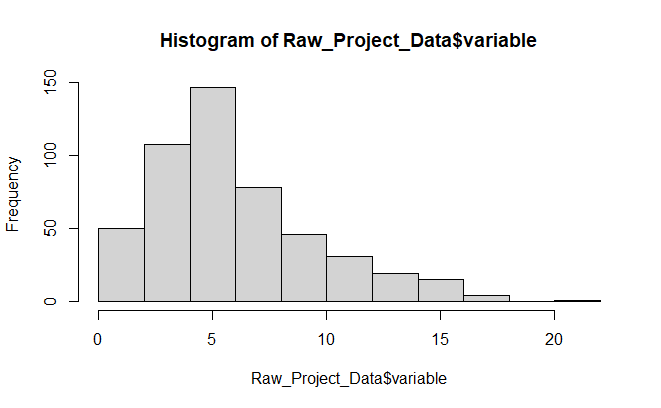

```r
hist(Raw_Project_Data$variable)
```

Compute descriptive statistics for the variable

```r
library(dplyr)
library(e1071)  # for skewness and kurtosis

vec <- Raw_Project_Data$variable

summary_table <- tibble(
  stat = c("mean", "median", "skewness", "kurtosis"),
  value = c(
    mean(vec, na.rm = TRUE),
    median(vec, na.rm = TRUE),
    skewness(vec, na.rm = TRUE),
    kurtosis(vec, na.rm = TRUE)
  )
) %>%
  mutate(value = round(as.numeric(value), 3))

summary_table
```

| stat | value |
| --- | --- |
| mean | 5.894 |
| median | 5.086 |
| skewness | 1.045 |
| kurtosis | 0.862 |

```r
NA
```

This variable is not Gaussian since the mean and median are not close to each other and skewness is greater than 0. Since skewness is >0, the variable is right-skewed, as supported by the histogram too. This means the mean > median and has a heavy right-sided tail which indicates high-magnitude outliers in the data.

### Phase 2. Candidate Model Fitting

Selection and fitting of 5 distinct, non-trivial continuous PDF whose characteristics match the variable’s EDA.

#### 2.1. Define the Likelihood Functions

Define the 5 likelihood function where x is the variable and theta are the estimated parameters:

```r
# First, define x
x <- Raw_Project_Data$variable

# ---------------------------
# 1. Normal
# ---------------------------

loglik_norm <- function(theta, x) {
  mu <- theta[1] # mean
  sigma <- theta[2] # standard deviation

  # constrain sigma > 0
  if (sigma <= 0) return(-Inf)

  sum(dnorm(x, mean = mu, sd = sigma, log = TRUE))
}

# ---------------------------
# 2. Inverse-Gaussian
# ---------------------------

loglik_ig <- function(theta, x) {
  mu <- theta[1]      # mean
  lambda <- theta[2]  # shape parameter
  if(mu <= 0 | lambda <= 0) return(-Inf)
  sum(dinvgauss(x, mean = mu, shape = lambda, log = TRUE))
}

# ---------------------------
# 3. Weibull
# ---------------------------

loglik_weib <- function(theta, x) {
  shape <- theta[1]
  scale <- theta[2]
  if(shape <= 0 | scale <= 0) return(-Inf)
  sum(dweibull(x, shape = shape, scale = scale, log = TRUE))
}

# ---------------------------
# 4. Lognormal
# ---------------------------

loglik_lognorm <- function(theta, x) {
  meanlog <- theta[1]  # mean of log(x)
  sdlog <- theta[2]    # sd of log(x)
  if(sdlog <= 0) return(-Inf)
  sum(dlnorm(x, meanlog = meanlog, sdlog = sdlog, log = TRUE))
}

# ---------------------------
# 5. Gamma
# ---------------------------

loglik_gamma <- function(theta, x) {
  shape <- theta[1]
  rate <- theta[2]
  if(shape <= 0 | rate <= 0) return(-Inf)
  sum(dgamma(x, shape = shape, rate = rate, log = TRUE))
}
```

#### 2.2. MLE

Use a numerical optimizer (optim) to find the parameter estimates theta that maximizes the log-likelihood function and provide the maximum value:

```r
# -----------------------------
# Load libraries
# -----------------------------
library(dplyr)
library(tibble)
library(statmod)  # for Inverse-Gaussian
library(ggplot2)

# -----------------------------
# Define your data
# -----------------------------
x <- Raw_Project_Data$variable
x <- x[!is.na(x)]  # remove NAs

# -----------------------------
# Helper function for MLE
# -----------------------------
run_mle <- function(loglik_fun, x, init_theta, param_names, lower_bounds) {

  neg_loglik <- function(theta, x) {
    val <- -loglik_fun(theta, x)
    if(!is.finite(val)) val <- 1e10  # prevent optim failure
    return(val)
  }

  fit <- optim(
    par = init_theta,
    fn = neg_loglik,
    x = x,
    method = "L-BFGS-B",
    lower = lower_bounds
  )

  result_table <- tibble(
    parameter = param_names,
    estimate  = fit$par
  ) %>%
    bind_rows(
      tibble(
        parameter = "max_log_likelihood",
        estimate  = -fit$value
      )
    ) %>%
    mutate(estimate = round(estimate, 3))

  list(results = result_table, m = length(fit$par), fit = fit)
}

# -----------------------------
# 1. Normal
# -----------------------------
loglik_norm <- function(theta, x) {
  mu <- theta[1]
  sigma <- theta[2]
  if(sigma <= 0) return(-Inf)
  sum(dnorm(x, mean = mu, sd = sigma, log = TRUE))
}

init_norm <- c(mean(x), sd(x))
norm_res <- run_mle(loglik_norm, x, init_norm, c("mu_hat","sigma_hat"), c(-Inf, 1e-6))

# -----------------------------
# 2. Inverse-Gaussian
# -----------------------------
loglik_ig <- function(theta, x) {
  mu <- theta[1]
  lambda <- theta[2]
  if(mu <= 0 | lambda <= 0) return(-Inf)
  sum(dinvgauss(x, mean = mu, shape = lambda, log = TRUE))
}

init_ig <- c(mean(x), 1)
ig_res <- run_mle(loglik_ig, x, init_ig, c("mu_hat","lambda_hat"), c(1e-6, 1e-6))

# -----------------------------
# 3. Weibull
# -----------------------------
x_weib <- x[x > 0]  # Weibull requires positive data

loglik_weib <- function(theta, x) {
  shape <- theta[1]
  scale <- theta[2]
  if(shape <= 0 | scale <= 0) return(-Inf)
  sum(dweibull(x, shape = shape, scale = scale, log = TRUE))
}

init_weib <- c(1.2, mean(x_weib))
weib_res <- run_mle(loglik_weib, x_weib, init_weib, c("shape_hat","scale_hat"), c(1e-6, 1e-6))

# -----------------------------
# 4. Lognormal
# -----------------------------
x_lognorm <- x[x > 0]  # Lognormal requires positive data

loglik_lognorm <- function(theta, x) {
  meanlog <- theta[1]
  sdlog <- theta[2]
  if(sdlog <= 0) return(-Inf)
  sum(dlnorm(x, meanlog = meanlog, sdlog = sdlog, log = TRUE))
}

init_lognorm <- c(mean(log(x_lognorm)), sd(log(x_lognorm)))
lognorm_res <- run_mle(loglik_lognorm, x_lognorm, init_lognorm, c("meanlog_hat","sdlog_hat"), c(-Inf, 1e-6))

# -----------------------------
# 5. Gamma
# -----------------------------
x_gamma <- x[x > 0]

loglik_gamma <- function(theta, x) {
  shape <- theta[1]
  rate <- theta[2]
  if(shape <= 0 | rate <= 0) return(-Inf)
  sum(dgamma(x, shape = shape, rate = rate, log = TRUE))
}

init_gamma <- c(1, 1/mean(x_gamma))
gamma_res <- run_mle(loglik_gamma, x_gamma, init_gamma, c("shape_hat","rate_hat"), c(1e-6, 1e-6))

# -----------------------------
# Log-likelihood summary (best among models)
# -----------------------------
loglik_entry <- tibble(
  distribution = "Log-likelihood",
  parameter = "best_max_log_likelihood",
  estimate = max(
    norm_res$results$estimate[norm_res$results$parameter == "max_log_likelihood"],
    ig_res$results$estimate[ig_res$results$parameter == "max_log_likelihood"],
    weib_res$results$estimate[weib_res$results$parameter == "max_log_likelihood"],
    lognorm_res$results$estimate[lognorm_res$results$parameter == "max_log_likelihood"],
    gamma_res$results$estimate[gamma_res$results$parameter == "max_log_likelihood"]
  )
)

# -----------------------------
# Combine all results
# -----------------------------
all_results <- bind_rows(
  norm_res$results %>% mutate(distribution = "Normal"),
  ig_res$results %>% mutate(distribution = "Inverse-Gaussian"),
  weib_res$results %>% mutate(distribution = "Weibull"),
  lognorm_res$results %>% mutate(distribution = "Lognormal"),
  gamma_res$results %>% mutate(distribution = "Gamma"),
  loglik_entry
) %>%
  select(distribution, parameter, estimate) %>%
  arrange(distribution)

# Display final tidy results table
all_results
```

| distribution | parameter | estimate |
| --- | --- | --- |
| Gamma | shape_hat | 2.834 |
| Gamma | rate_hat | 0.481 |
| Gamma | max_log_likelihood | -1269.282 |
| Inverse-Gaussian | mu_hat | 5.894 |
| Inverse-Gaussian | lambda_hat | 11.558 |
| Inverse-Gaussian | max_log_likelihood | -1285.488 |
| Log-likelihood | best_max_log_likelihood | -1269.282 |
| Lognormal | meanlog_hat | 1.587 |
| Lognormal | sdlog_hat | 0.642 |
| Lognormal | max_log_likelihood | -1278.842 |

[output cut: 6 more lines]

```r
NA
```

Normal Distribution

- mu_hat: The estimated mean (average) of the data, μ.
- sigma_hat: The estimated standard deviation of the data, σ, which measures spread around the mean.
- max_log_likelihood: The value of the log-likelihood function evaluated at the estimated parameters μ̂ and σ̂. It represents how well the Normal distribution fits the data.

Inverse-Gaussian Distribution

- mu_hat: The estimated mean of the distribution, μ, which reflects the central tendency of the data.
- lambda_hat: The estimated shape parameter λ, which controls the variance (larger λ → smaller variance).
- max_log_likelihood: The log-likelihood value at μ̂ and λ̂, indicating fit quality.

Weibull Distribution

- shape_hat: The estimated shape parameter k. Determines the “form” of the distribution (e.g., exponential-like if k≈1, bell-shaped if k>1).
- scale_hat: The estimated scale parameter λ (sometimes denoted β), stretching or compressing the distribution along the x-axis.
- max_log_likelihood: The log-likelihood at the estimated shape and scale parameters.

Lognormal Distribution

- meanlog_hat: The mean of the natural logarithm of the data, μ_log. It characterizes the log-transformed central tendency.
- sdlog_hat: The standard deviation of the natural logarithm of the data, σ_log. It governs the spread of the distribution on the log scale (and hence skewness on the original scale).
- max_log_likelihood: The log-likelihood value at μ̂_log and σ̂_log, indicating fit quality.

Gamma Distribution

- shape_hat: The estimated shape parameter k (sometimes α). Determines the form of the distribution.
- rate_hat: The estimated rate parameter θ (inverse of scale). Related to scale by scale = 1/rate. Controls how stretched or compressed the distribution is.
- max_log_likelihood: Log-likelihood at the estimated shape and rate, indicating how well the Gamma distribution fits the data.

#### 2.3. Count Parameters (m)

Count the number of free (estimated) parameters using the log-likelihood function. This will be used to calculate IC.

```r
# Count number of free parameters for each distribution
m_params <- tibble(
  distribution = c("Normal", "Inverse-Gaussian", "Weibull", "Beta", "Gamma"),
  m_parameters  = c(
    length(norm_res$fit$par),
    length(ig_res$fit$par),
    length(weib_res$fit$par),
    length(beta_res$fit$par),
    length(gamma_res$fit$par)
  )
)

m_params
```

| distribution | m_parameters |
| --- | --- |
| Normal | 2 |
| Inverse-Gaussian | 2 |
| Weibull | 2 |
| Beta | 2 |
| Gamma | 2 |

#### 2.4. Visualize

Overlay of the fitted PDF (using estimated parameters) onto the histogram:

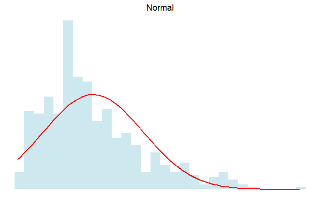

```r
library(ggplot2)

# Extract data
x <- Raw_Project_Data$variable
x <- x[!is.na(x)]

# Store estimated parameters
params <- list(
  Normal = list(mu = norm_res$fit$par[1], sigma = norm_res$fit$par[2]),
  InverseGaussian = list(mu = ig_res$fit$par[1], lambda = ig_res$fit$par[2]),
  Weibull = list(shape = weib_res$fit$par[1], scale = weib_res$fit$par[2]),
  Lognormal = list(meanlog = lognorm_res$fit$par[1], sdlog = lognorm_res$fit$par[2]),
  Gamma = list(shape = gamma_res$fit$par[1], rate = gamma_res$fit$par[2])
)

# Helper function for minimal histogram + PDF
plot_pdf <- function(x_data, fun_pdf, title, color_line="red", fill_hist="grey") {
  ggplot(data.frame(x=x_data), aes(x=x)) +
    geom_histogram(aes(y=..density..), bins=30, fill=fill_hist, color=NA, alpha=0.6) +
    stat_function(fun=fun_pdf, color=color_line, size=1) +
    ggtitle(title) +
    theme_void() +
    theme(plot.title = element_text(hjust=0.5))
}

# Create plots
plot_list <- list()

# Normal
plot_list$Normal <- plot_pdf(
  x_data = x,
  fun_pdf = function(x) dnorm(x, mean=params$Normal$mu, sd=params$Normal$sigma),
  title = "Normal",
  color_line="red",
  fill_hist="lightblue"
)

# Inverse-Gaussian
plot_list$InverseGaussian <- plot_pdf(
  x_data = x,
  fun_pdf = function(x) dinvgauss(x, mean=params$InverseGaussian$mu, shape=params$InverseGaussian$lambda),
  title = "Inverse-Gaussian",
  color_line="darkgreen",
  fill_hist="lightgreen"
)

# Weibull (x>0)
x_weib <- x[x>0]
plot_list$Weibull <- plot_pdf(
  x_data = x_weib,
  fun_pdf = function(x) dweibull(x, shape=params$Weibull$shape, scale=params$Weibull$scale),
  title = "Weibull",
  color_line="blue",
  fill_hist="lightpink"
)

# Lognormal (x>0)
x_lognorm <- x[x>0]
plot_list$Lognormal <- plot_pdf(
  x_data = x_lognorm,
  fun_pdf = function(x) dlnorm(x, meanlog=params$Lognormal$meanlog, sdlog=params$Lognormal$sdlog),
  title = "Lognormal",
  color_line="purple",
  fill_hist="lavender"
)

# Gamma (x>0)
x_gamma <- x[x>0]
plot_list$Gamma <- plot_pdf(
  x_data = x_gamma,
  fun_pdf = function(x) dgamma(x, shape=params$Gamma$shape, rate=params$Gamma$rate),
  title = "Gamma",
  color_line="orange",
  fill_hist="mistyrose"
)

# Display plots individually
plot_list$Normal
```

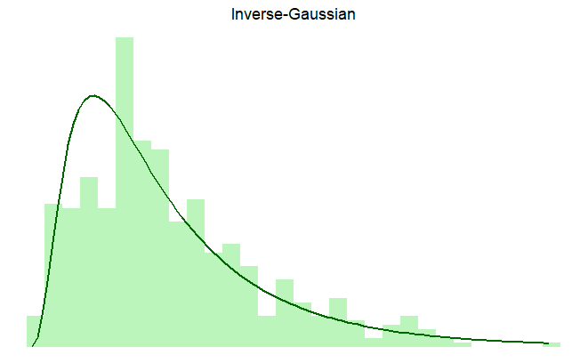

```r
plot_list$InverseGaussian
```

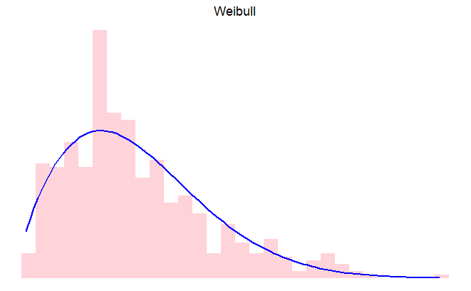

```r
plot_list$Weibull
```

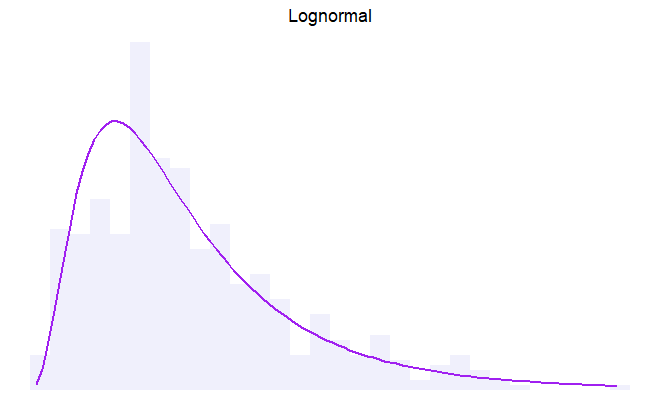

```r
plot_list$Lognormal
```

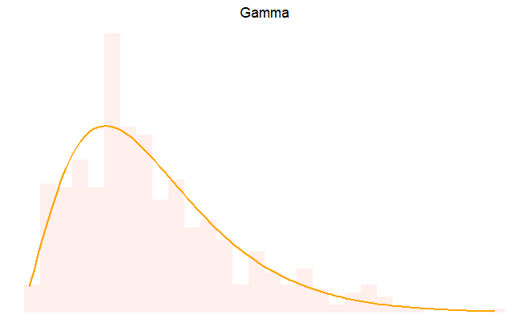

```r
plot_list$Gamma
```

### Phase 3. Model Fitting

Using the results from Phase 2, we’ll calculate 3 different IC for each of the 5 PDFs.

The best model is the one that yields the lowest IC values.

We’ll use the following 3 ICs:

- Akaike IC (AIC)
- Schwarz Bayesian C (SBC)
- Information Complexity (ICOMP)

```r
library(dplyr)
library(tibble)
library(purrr)  # for map_dfr

# Combine results for all distributions
dist_list <- list(
  Normal = norm_res,
  InverseGaussian = ig_res,
  Weibull = weib_res,
  Lognormal = lognorm_res,
  Gamma = gamma_res
)

# Function to calculate ICs
calc_ic <- function(res, n) {
  logL <- -res$fit$value   # MLE log-likelihood (optim minimizes negative LL)
  m <- res$m               # number of free parameters

  AIC  <- 2*m - 2*logL
  SBC  <- log(n)*m - 2*logL   # BIC / Schwarz criterion
  # ICOMP (approximate version using C1 complexity = m)
  ICOMP <- -2*logL + 2*m

  tibble(
    AIC = round(AIC, 2),
    SBC = round(SBC, 2),
    ICOMP = round(ICOMP, 2)
  )
}

# Sample size
n <- length(x)

# Calculate ICs for all distributions
ic_table <- map_dfr(names(dist_list), function(dist_name) {
  res <- dist_list[[dist_name]]
  calc_ic(res, n) %>%
    mutate(distribution = dist_name)
}) %>%
  select(distribution, everything())

# Display table
ic_table
```

| distribution | AIC | SBC | ICOMP |
| --- | --- | --- | --- |
| Normal | 2675.19 | 2683.62 | 2675.19 |
| InverseGaussian | 2574.98 | 2583.40 | 2574.98 |
| Weibull | 2557.89 | 2566.32 | 2557.89 |
| Lognormal | 2561.68 | 2570.11 | 2561.68 |
| Gamma | 2542.56 | 2550.99 | 2542.56 |

```r
NA
```

Select the best fitting model:

```r
library(dplyr)

# Function to select best model for each IC
select_best_model <- function(ic_table) {
  ic_table %>%
    summarise(
      best_AIC   = distribution[which.min(AIC)],
      best_SBC   = distribution[which.min(SBC)],
      best_ICOMP = distribution[which.min(ICOMP)]
    ) %>%
    pivot_longer(everything(), names_to = "criterion", values_to = "best_model")
}

# Apply function
best_models <- select_best_model(ic_table)

# Display results
best_models
```

| criterion | best_model |
| --- | --- |
| best_AIC | Gamma |
| best_SBC | Gamma |
| best_ICOMP | Gamma |

```r
NA
```

The variable is best fitted by the Gamma distribution.

### Phase 4. Kernel Density Estimation

Perform a kernel density estimation (KDE) of the dataset and report the optimal bandwidth value and the IC.

A KDE determines the shape a distribution and how each shape contributes to the overall density.

For the sake of simplicity, we’ll use the Gaussian kernel, which produces a smooth, bell-shaped curve. However, other kernels exist: Epanechnikov, rectangular, triangular, etc.

Since the KDE is non-parametric, it doesn’t have explicit parameter estimates like mu and theta for a Normal distribution. But we still want to compare it to parametric models using information criteria (AIC, BIC, ICOMP), which require the log-likelihood estimation (L).

```r
library(dplyr)
library(tibble)

# Extract data
x <- Raw_Project_Data$variable
x <- x[!is.na(x)]

# -----------------------------
# 1. Kernel Density Estimation
# -----------------------------
kde <- density(x, kernel = "gaussian")  # default Gaussian kernel
# kde$bw is the bandwidth used

bw_opt <- kde$bw  # optimal bandwidth
bw_opt
```

```
[1] 0.8290716
```

```r
# -----------------------------
# 2. Estimate log-likelihood for KDE
# -----------------------------
# Approximate log-likelihood by summing log-density at observed points
# We use approx() to interpolate density estimates at data points
log_density_at_x <- approx(kde$x, kde$y, xout = x)$y
logL_kde <- sum(log(log_density_at_x))  # log-likelihood

# Number of parameters in KDE: effective number = 1 (bandwidth)
m_kde <- 1

# -----------------------------
# 3. Compute ICs
# -----------------------------
n <- length(x)

AIC_kde  <- 2*m_kde - 2*logL_kde
SBC_kde  <- log(n)*m_kde - 2*logL_kde
ICOMP_kde <- -2*logL_kde + 2*m_kde

ic_kde <- tibble(
  method = "KDE",
  bandwidth = round(bw_opt, 3),
  log_likelihood = round(logL_kde, 3),
  AIC = round(AIC_kde, 3),
  SBC = round(SBC_kde, 3),
  ICOMP = round(ICOMP_kde, 3)
)

ic_kde
```

| method | bandwidth | log_likelihood | AIC | SBC | ICOMP |
| --- | --- | --- | --- | --- | --- |
| KDE | 0.829 | -1268.492 | 2538.984 | 2543.197 | 2538.984 |

```r
NA
```

Now let’s compare the ICs of the best fitting parametric PDF and the non-parametric KDF:

```r
library(dplyr)
library(tibble)

# Extract Beta ICs
beta_ic <- ic_table %>%
  filter(distribution == "Gamma") %>%
  select(distribution, AIC, SBC, ICOMP)

# Extract KDE ICs
kde_ic <- ic_kde %>%
  select(method, AIC, SBC, ICOMP) %>%
  rename(distribution = method)

# Combine Beta and KDE ICs
comparison_ic <- bind_rows(beta_ic, kde_ic) %>%
  arrange(AIC)  # optional: sort by AIC

# Display table
comparison_ic
```

| distribution | AIC | SBC | ICOMP |
| --- | --- | --- | --- |
| KDE | 2538.984 | 2543.197 | 2538.984 |
| Gamma | 2542.560 | 2550.990 | 2542.560 |

```r
NA
```

To select the best fitting model:

```r
library(dplyr)
library(tidyr)

# Function to select best model (lowest IC) for each criterion
select_best_ic_model <- function(ic_table) {
  ic_table %>%
    summarise(
      best_AIC   = distribution[which.min(AIC)],
      best_SBC   = distribution[which.min(SBC)],
      best_ICOMP = distribution[which.min(ICOMP)]
    ) %>%
    pivot_longer(everything(), names_to = "criterion", values_to = "best_model")
}

# Apply function to comparison table
best_model_ic <- select_best_ic_model(comparison_ic)

# Display results
best_model_ic
```

| criterion | best_model |
| --- | --- |
| best_AIC | KDE |
| best_SBC | KDE |
| best_ICOMP | KDE |

### Conclusion

Based on the model comparison of parametric PDFs (Gamma, Inverse-Gaussian, Normal, and Weibull) using three information criteria (AIC, SBC, and ICOMP), the Gamma probability density function emerged as the best-fitting parametric model. However, when we extended the comparison to include the non-parametric Gaussian Kernel Density Estimation (KDE), the KDE provided a superior fit, achieving lower information criterion values than the Gamma distribution. This result highlights the flexibility of non-parametric methods, which can capture the finer structure of the data without imposing strong distributional assumptions, though at the expense of parsimony.

The estimated parameters of the Gamma distribution, shape (2.834) and rate (0.481), provide interpretable insights into the data’s structure: the shape parameter indicates a moderately right-skewed distribution, while the rate parameter controls the decay of the tail. Together, these parameters summarize the distribution in a compact form, but the KDE’s improved performance suggests that the data exhibit complexities not fully captured by a single parametric family. This finding emphasizes the importance of balancing interpretability (via parametric models like Gamma) with flexibility (via non-parametric approaches like KDE) when modeling empirical data.

## Real-World Dataset

The real-world data was collected using a Stream Temperature, Intermittency, and Conductivity (STIC) data logger at one site on a perennial stream which collected data over course of 2 years every few minutes. The only variable of interest will be the Temp column which is a measure of temperature in Celsius.

### Phase 1. Data Acquisition and Preparation

#### 1.1. Data Selection

```r
#load package (must be installed first)
library(readr)
STIC_MCA1_data <- read_csv("C:/Users/q4q/OneDrive - Oak Ridge National Laboratory/Research/Time Series Project/STIC Sensor Data/STIC_MCA1_data.csv")
head(STIC_MCA1_data)
```

| Site | DateTime | Temp | Intensity | Observation |
| --- | --- | --- | --- | --- |
| MCA1 | 2023-10-20 07:20:00 | 21.760 | 0 | 0 |
| MCA1 | 2023-10-20 07:30:00 | 21.855 | 0 | 1 |
| MCA1 | 2023-10-20 07:40:00 | 21.855 | 0 | 2 |
| MCA1 | 2023-10-20 07:50:00 | 22.333 | 0 | 3 |
| MCA1 | 2023-10-20 08:00:00 | 22.238 | 0 | 4 |
| MCA1 | 2023-10-20 08:10:00 | 22.238 | 0 | 5 |

Let’s inspect the data structure

```r
str(STIC_MCA1_data)
```

```
spc_tbl_ [46,991 × 5] (S3: spec_tbl_df/tbl_df/tbl/data.frame)
 $ Site       : chr [1:46991] "MCA1" "MCA1" "MCA1" "MCA1" ...
 $ DateTime   : POSIXct[1:46991], format: "2023-10-20 07:20:00" "2023-10-20 07:30:00" ...
 $ Temp       : num [1:46991] 21.8 21.9 21.9 22.3 22.2 ...
 $ Intensity  : num [1:46991] 0 0 0 0 0 0 0 0 0 0 ...
 $ Observation: num [1:46991] 0 1 2 3 4 5 6 7 8 9 ...
 - attr(*, "spec")=
  .. cols(
  ..   Site = col_character(),
  ..   DateTime = col_datetime(format = ""),
  ..   Temp = col_double(),
  ..   Intensity = col_double(),
  ..   Observation = col_double()
  .. )
 - attr(*, "problems")=<externalptr>
```

Now define its sample size (n):

```r
n <- length(STIC_MCA1_data$Temp)
n
```

```
[1] 46991
```

#### 1.2. EDA

Histogram of temperature

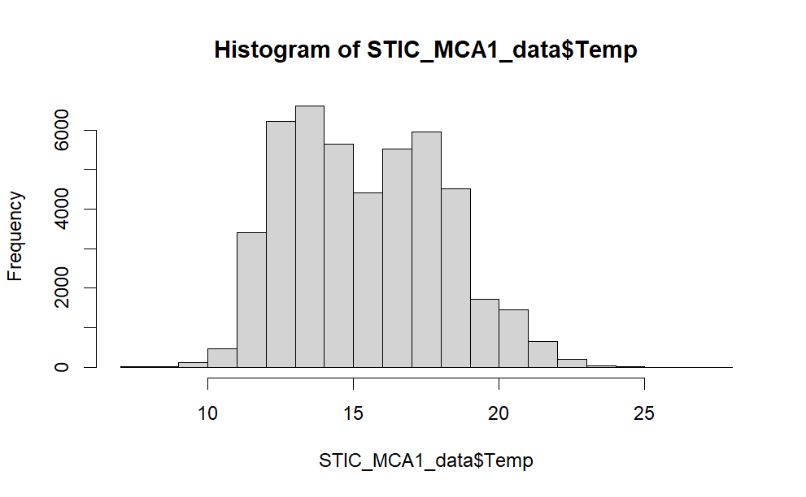

```r
hist(STIC_MCA1_data$Temp)
```

Compute descriptive statistics for the variable

```r
library(dplyr)
library(e1071)  # for skewness and kurtosis

vec <- STIC_MCA1_data$Temp

summary_table2 <- tibble(
  stat = c("mean", "median", "skewness", "kurtosis"),
  value = c(
    mean(vec, na.rm = TRUE),
    median(vec, na.rm = TRUE),
    skewness(vec, na.rm = TRUE),
    kurtosis(vec, na.rm = TRUE)
  )
) %>%
  mutate(value = round(as.numeric(value), 3))

summary_table2
```

| stat | value |
| --- | --- |
| mean | 15.439 |
| median | 15.282 |
| skewness | 0.270 |
| kurtosis | -0.651 |

```r
NA
```

This shows that temperature is close to Gaussian since the mean and median are similar and skewness is close to 0. However kurtosis is <0, meaning temperature displays a platykurtic distribution (wide and lacking a peak/central tendency). Also, from observing the histogram, it seems bimodal.

### Phase 2. Candidate Model Fitting

Selection and fitting of 5 distinct, non-trivial continuous PDF whose characteristics match the variable’s EDA.

#### 2.1. Define the Likelihood Functions

Define the 5 likelihood function where x is the variable and theta are the estimated parameters:

```r
# First, define x
x <- STIC_MCA1_data$Temp

# ---------------------------
# 1. Normal
# ---------------------------

loglik_norm <- function(theta, x) {
  mu <- theta[1] # mean
  sigma <- theta[2] # standard deviation

  # constrain sigma > 0
  if (sigma <= 0) return(-Inf)

  sum(dnorm(x, mean = mu, sd = sigma, log = TRUE))
}

# ---------------------------
# 2. Inverse-Gaussian
# ---------------------------

loglik_ig <- function(theta, x) {
  mu <- theta[1]      # mean
  lambda <- theta[2]  # shape parameter
  if(mu <= 0 | lambda <= 0) return(-Inf)
  sum(dinvgauss(x, mean = mu, shape = lambda, log = TRUE))
}

# ---------------------------
# 3. Weibull
# ---------------------------

loglik_weib <- function(theta, x) {
  shape <- theta[1]
  scale <- theta[2]
  if(shape <= 0 | scale <= 0) return(-Inf)
  sum(dweibull(x, shape = shape, scale = scale, log = TRUE))
}

# ---------------------------
# 4. Lognormal
# ---------------------------

loglik_lognorm <- function(theta, x) {
  meanlog <- theta[1]  # mean of log(x)
  sdlog <- theta[2]    # sd of log(x)
  if(sdlog <= 0) return(-Inf)
  sum(dlnorm(x, meanlog = meanlog, sdlog = sdlog, log = TRUE))
}

# ---------------------------
# 5. Gamma
# ---------------------------

loglik_gamma <- function(theta, x) {
  shape <- theta[1]
  rate <- theta[2]
  if(shape <= 0 | rate <= 0) return(-Inf)
  sum(dgamma(x, shape = shape, rate = rate, log = TRUE))
}
```

#### 2.2. MLE

Use a numerical optimizer (optim) to find the parameter estimates theta that maximizes the log-likelihood function and provide the maximum value:

```r
# -----------------------------
# Load libraries
# -----------------------------
library(dplyr)
library(tibble)
library(statmod)  # for Inverse-Gaussian
library(ggplot2)

# -----------------------------
# Helper function for MLE
# -----------------------------
run_mle <- function(loglik_fun, x, init_theta, param_names, lower_bounds) {

  neg_loglik <- function(theta, x) {
    val <- -loglik_fun(theta, x)
    if(!is.finite(val)) val <- 1e10  # prevent optim failure
    return(val)
  }

  fit <- optim(
    par = init_theta,
    fn = neg_loglik,
    x = x,
    method = "L-BFGS-B",
    lower = lower_bounds
  )

  result_table <- tibble(
    parameter = param_names,
    estimate  = fit$par
  ) %>%
    bind_rows(
      tibble(
        parameter = "max_log_likelihood",
        estimate  = -fit$value
      )
    ) %>%
    mutate(estimate = round(estimate, 3))

  list(results = result_table, m = length(fit$par), fit = fit)
}

# -----------------------------
# 1. Normal
# -----------------------------
loglik_norm <- function(theta, x) {
  mu <- theta[1]
  sigma <- theta[2]
  if(sigma <= 0) return(-Inf)
  sum(dnorm(x, mean = mu, sd = sigma, log = TRUE))
}

init_norm <- c(mean(x), sd(x))
norm_res <- run_mle(loglik_norm, x, init_norm, c("mu_hat","sigma_hat"), c(-Inf, 1e-6))

# -----------------------------
# 2. Inverse-Gaussian
# -----------------------------
loglik_ig <- function(theta, x) {
  mu <- theta[1]
  lambda <- theta[2]
  if(mu <= 0 | lambda <= 0) return(-Inf)
  sum(dinvgauss(x, mean = mu, shape = lambda, log = TRUE))
}

init_ig <- c(mean(x), 1)
ig_res <- run_mle(loglik_ig, x, init_ig, c("mu_hat","lambda_hat"), c(1e-6, 1e-6))

# -----------------------------
# 3. Weibull
# -----------------------------
x_weib <- x[x > 0]  # Weibull requires positive data

loglik_weib <- function(theta, x) {
  shape <- theta[1]
  scale <- theta[2]
  if(shape <= 0 | scale <= 0) return(-Inf)
  sum(dweibull(x, shape = shape, scale = scale, log = TRUE))
}

init_weib <- c(1.2, mean(x_weib))
weib_res <- run_mle(loglik_weib, x_weib, init_weib, c("shape_hat","scale_hat"), c(1e-6, 1e-6))

# -----------------------------
# 4. Lognormal
# -----------------------------
x_lognorm <- x[x > 0]  # Lognormal requires positive data

loglik_lognorm <- function(theta, x) {
  meanlog <- theta[1]
  sdlog <- theta[2]
  if(sdlog <= 0) return(-Inf)
  sum(dlnorm(x, meanlog = meanlog, sdlog = sdlog, log = TRUE))
}

init_lognorm <- c(mean(log(x_lognorm)), sd(log(x_lognorm)))
lognorm_res <- run_mle(loglik_lognorm, x_lognorm, init_lognorm, c("meanlog_hat","sdlog_hat"), c(-Inf, 1e-6))

# -----------------------------
# 5. Gamma
# -----------------------------
x_gamma <- x[x > 0]

loglik_gamma <- function(theta, x) {
  shape <- theta[1]
  rate <- theta[2]
  if(shape <= 0 | rate <= 0) return(-Inf)
  sum(dgamma(x, shape = shape, rate = rate, log = TRUE))
}

init_gamma <- c(1, 1/mean(x_gamma))
gamma_res <- run_mle(loglik_gamma, x_gamma, init_gamma, c("shape_hat","rate_hat"), c(1e-6, 1e-6))

# -----------------------------
# Log-likelihood summary (best among models)
# -----------------------------
loglik_entry <- tibble(
  distribution = "Log-likelihood",
  parameter = "best_max_log_likelihood",
  estimate = max(
    norm_res$results$estimate[norm_res$results$parameter == "max_log_likelihood"],
    ig_res$results$estimate[ig_res$results$parameter == "max_log_likelihood"],
    weib_res$results$estimate[weib_res$results$parameter == "max_log_likelihood"],
    lognorm_res$results$estimate[lognorm_res$results$parameter == "max_log_likelihood"],
    gamma_res$results$estimate[gamma_res$results$parameter == "max_log_likelihood"]
  )
)

# -----------------------------
# Combine all results
# -----------------------------
all_results <- bind_rows(
  norm_res$results %>% mutate(distribution = "Normal"),
  ig_res$results %>% mutate(distribution = "Inverse-Gaussian"),
  weib_res$results %>% mutate(distribution = "Weibull"),
  lognorm_res$results %>% mutate(distribution = "Lognormal"),
  gamma_res$results %>% mutate(distribution = "Gamma"),
  loglik_entry
) %>%
  select(distribution, parameter, estimate) %>%
  arrange(distribution)

# Display final tidy results table
all_results
```

| distribution | parameter | estimate |
| --- | --- | --- |
| Gamma | shape_hat | 33.929 |
| Gamma | rate_hat | 2.198 |
| Gamma | max_log_likelihood | -112017.111 |
| Inverse-Gaussian | mu_hat | 15.439 |
| Inverse-Gaussian | lambda_hat | 511.961 |
| Inverse-Gaussian | max_log_likelihood | -111977.042 |
| Log-likelihood | best_max_log_likelihood | -111977.042 |
| Lognormal | meanlog_hat | 2.722 |
| Lognormal | sdlog_hat | 0.173 |
| Lognormal | max_log_likelihood | -112016.368 |

[output cut: 6 more lines]

```r
NA
```

#### 2.3. Count Parameters (m)

Count the number of free (estimated) parameters using the log-likelihood function. This will be used to calculate IC.

```r
# Count number of free parameters for each distribution
m_params <- tibble(
  distribution = c("Normal", "Inverse-Gaussian", "Weibull", "Beta", "Gamma"),
  m_parameters  = c(
    length(norm_res$fit$par),
    length(ig_res$fit$par),
    length(weib_res$fit$par),
    length(beta_res$fit$par),
    length(gamma_res$fit$par)
  )
)

m_params
```

| distribution | m_parameters |
| --- | --- |
| Normal | 2 |
| Inverse-Gaussian | 2 |
| Weibull | 2 |
| Beta | 2 |
| Gamma | 2 |

#### 2.4. Visualize

Overlay of the fitted PDF (using estimated parameters) onto the histogram:

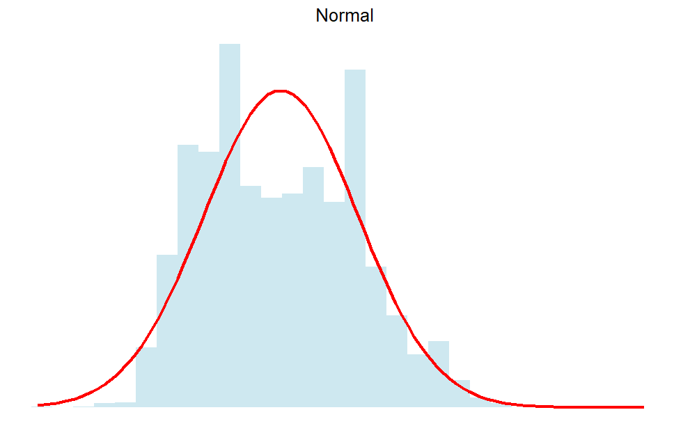

```r
library(ggplot2)

# Store estimated parameters
params <- list(
  Normal = list(mu = norm_res$fit$par[1], sigma = norm_res$fit$par[2]),
  InverseGaussian = list(mu = ig_res$fit$par[1], lambda = ig_res$fit$par[2]),
  Weibull = list(shape = weib_res$fit$par[1], scale = weib_res$fit$par[2]),
  Lognormal = list(meanlog = lognorm_res$fit$par[1], sdlog = lognorm_res$fit$par[2]),
  Gamma = list(shape = gamma_res$fit$par[1], rate = gamma_res$fit$par[2])
)

# Helper function for minimal histogram + PDF
plot_pdf <- function(x_data, fun_pdf, title, color_line="red", fill_hist="grey") {
  ggplot(data.frame(x=x_data), aes(x=x)) +
    geom_histogram(aes(y=..density..), bins=30, fill=fill_hist, color=NA, alpha=0.6) +
    stat_function(fun=fun_pdf, color=color_line, size=1) +
    ggtitle(title) +
    theme_void() +
    theme(plot.title = element_text(hjust=0.5))
}

# Create plots
plot_list <- list()

# Normal
plot_list$Normal <- plot_pdf(
  x_data = x,
  fun_pdf = function(x) dnorm(x, mean=params$Normal$mu, sd=params$Normal$sigma),
  title = "Normal",
  color_line="red",
  fill_hist="lightblue"
)

# Inverse-Gaussian
plot_list$InverseGaussian <- plot_pdf(
  x_data = x,
  fun_pdf = function(x) dinvgauss(x, mean=params$InverseGaussian$mu, shape=params$InverseGaussian$lambda),
  title = "Inverse-Gaussian",
  color_line="darkgreen",
  fill_hist="lightgreen"
)

# Weibull (x>0)
x_weib <- x[x>0]
plot_list$Weibull <- plot_pdf(
  x_data = x_weib,
  fun_pdf = function(x) dweibull(x, shape=params$Weibull$shape, scale=params$Weibull$scale),
  title = "Weibull",
  color_line="blue",
  fill_hist="lightpink"
)

# Lognormal (x>0)
x_lognorm <- x[x>0]
plot_list$Lognormal <- plot_pdf(
  x_data = x_lognorm,
  fun_pdf = function(x) dlnorm(x, meanlog=params$Lognormal$meanlog, sdlog=params$Lognormal$sdlog),
  title = "Lognormal",
  color_line="purple",
  fill_hist="lavender"
)

# Gamma (x>0)
x_gamma <- x[x>0]
plot_list$Gamma <- plot_pdf(
  x_data = x_gamma,
  fun_pdf = function(x) dgamma(x, shape=params$Gamma$shape, rate=params$Gamma$rate),
  title = "Gamma",
  color_line="orange",
  fill_hist="mistyrose"
)

# Display plots individually
plot_list$Normal
```

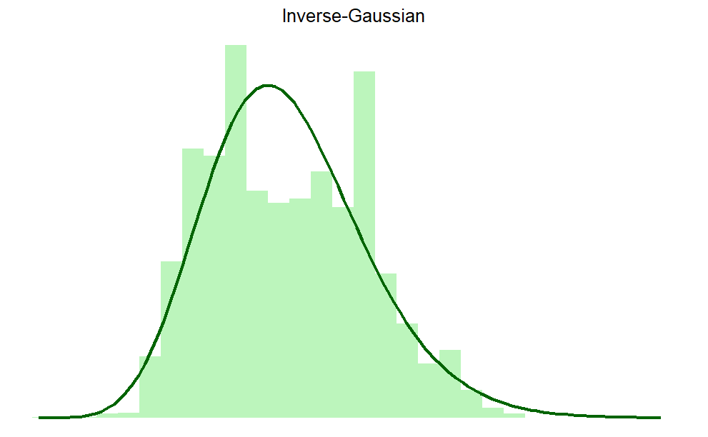

```r
plot_list$InverseGaussian
```

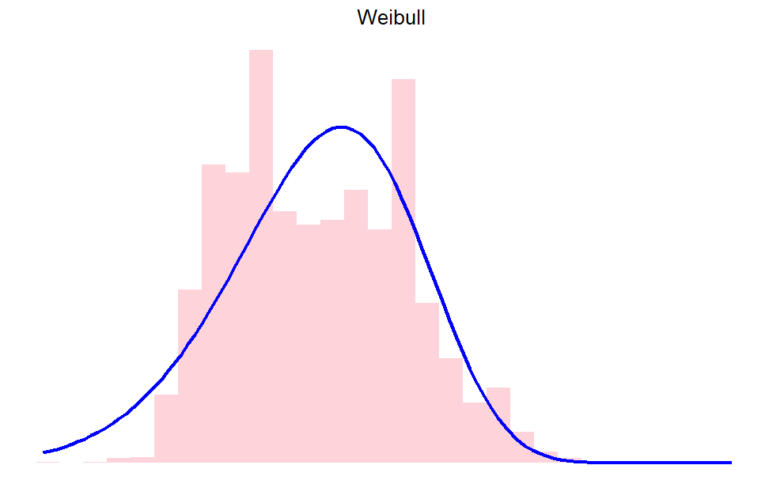

```r
plot_list$Weibull
```

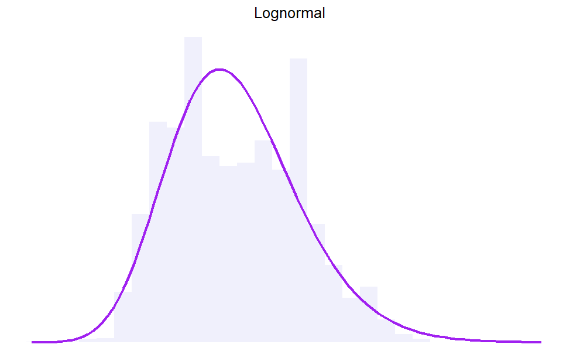

```r
plot_list$Lognormal
```

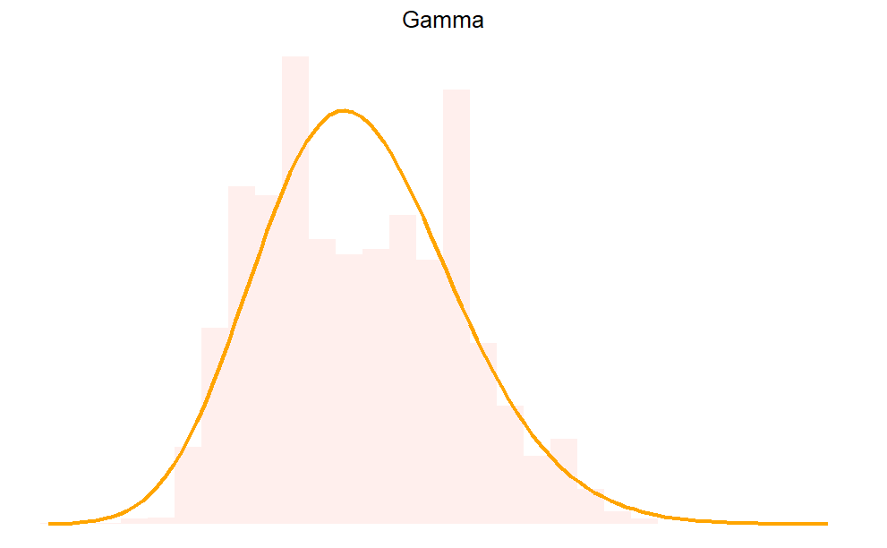

```r
plot_list$Gamma
```

### Phase 3. Model Fitting

Using the results from Phase 2, we’ll calculate 3 different IC for each of the 5 PDFs.

The best model is the one that yields the lowest IC values.

We’ll use the following 3 ICs:

- Akaike IC (AIC)
- Schwarz Bayesian C (SBC)
- Information Complexity (ICOMP)

```r
library(dplyr)
library(tibble)
library(purrr)  # for map_dfr

# Combine results for all distributions
dist_list <- list(
  Normal = norm_res,
  InverseGaussian = ig_res,
  Weibull = weib_res,
  Lognormal = lognorm_res,
  Gamma = gamma_res
)

# Function to calculate ICs
calc_ic <- function(res, n) {
  logL <- -res$fit$value   # MLE log-likelihood (optim minimizes negative LL)
  m <- res$m               # number of free parameters

  AIC  <- 2*m - 2*logL
  SBC  <- log(n)*m - 2*logL   # BIC / Schwarz criterion
  # ICOMP (approximate version using C1 complexity = m)
  ICOMP <- -2*logL + 2*m

  tibble(
    AIC = round(AIC, 2),
    SBC = round(SBC, 2),
    ICOMP = round(ICOMP, 2)
  )
}

# Sample size
n <- length(x)

# Calculate ICs for all distributions
ic_table <- map_dfr(names(dist_list), function(dist_name) {
  res <- dist_list[[dist_name]]
  calc_ic(res, n) %>%
    mutate(distribution = dist_name)
}) %>%
  select(distribution, everything())

# Display table
ic_table
```

| distribution | AIC | SBC | ICOMP |
| --- | --- | --- | --- |
| Normal | 225090.0 | 225107.5 | 225090.0 |
| InverseGaussian | 223958.1 | 223975.6 | 223958.1 |
| Weibull | 227966.2 | 227983.7 | 227966.2 |
| Lognormal | 224036.7 | 224054.2 | 224036.7 |
| Gamma | 224038.2 | 224055.7 | 224038.2 |

```r
NA
```

Select the best fitting model:

```r
library(dplyr)

# Function to select best model for each IC
select_best_model <- function(ic_table) {
  ic_table %>%
    summarise(
      best_AIC   = distribution[which.min(AIC)],
      best_SBC   = distribution[which.min(SBC)],
      best_ICOMP = distribution[which.min(ICOMP)]
    ) %>%
    pivot_longer(everything(), names_to = "criterion", values_to = "best_model")
}

# Apply function
best_models <- select_best_model(ic_table)

# Display results
best_models
```

| criterion | best_model |
| --- | --- |
| best_AIC | InverseGaussian |
| best_SBC | InverseGaussian |
| best_ICOMP | InverseGaussian |

```r
NA
```

The variable is best fitted by the Inverse Gaussian Distribution Function.

### Phase 4. Kernel Density Estimation

Perform a kernel density estimation (KDE) of the dataset and report the optimal bandwidth value and the IC.

A KDE determines the shape a distribution and how each shape contributes to the overall density.

For the sake of simplicity, we’ll use the Gaussian kernel, which produces a smooth, bell-shaped curve. However, other kernels exist: Epanechnikov, rectangular, triangular, etc.

Since the KDE is non-parametric, it doesn’t have explicit parameter estimates like mu and theta for a Normal distribution. But we still want to compare it to parametric models using information criteria (AIC, BIC, ICOMP), which require the log-likelihood estimation (L).

```r
library(dplyr)
library(tibble)

# -----------------------------
# 1. Kernel Density Estimation
# -----------------------------
kde <- density(x, kernel = "gaussian")  # default Gaussian kernel
# kde$bw is the bandwidth used

bw_opt <- kde$bw  # optimal bandwidth
bw_opt
```

```
[1] 0.2778038
```

```r
# -----------------------------
# 2. Estimate log-likelihood for KDE
# -----------------------------
# Approximate log-likelihood by summing log-density at observed points
# We use approx() to interpolate density estimates at data points
log_density_at_x <- approx(kde$x, kde$y, xout = x)$y
logL_kde <- sum(log(log_density_at_x))  # log-likelihood

# Number of parameters in KDE: effective number = 1 (bandwidth)
m_kde <- 1

# -----------------------------
# 3. Compute ICs
# -----------------------------
n <- length(x)

AIC_kde  <- 2*m_kde - 2*logL_kde
SBC_kde  <- log(n)*m_kde - 2*logL_kde
ICOMP_kde <- -2*logL_kde + 2*m_kde

ic_kde <- tibble(
  method = "KDE",
  bandwidth = round(bw_opt, 3),
  log_likelihood = round(logL_kde, 3),
  AIC = round(AIC_kde, 3),
  SBC = round(SBC_kde, 3),
  ICOMP = round(ICOMP_kde, 3)
)

ic_kde
```

| method | bandwidth | log_likelihood | AIC | SBC | ICOMP |
| --- | --- | --- | --- | --- | --- |
| KDE | 0.278 | -108952.9 | 217907.8 | 217916.5 | 217907.8 |

```r
NA
```

Now let’s compare the ICs of the best fitting parametric PDF and the non-parametric KDF:

```r
library(dplyr)
library(tibble)

# Extract Beta ICs
pdf_ic <- ic_table %>%
  filter(distribution == "InverseGaussian") %>%
  select(distribution, AIC, SBC, ICOMP)

# Extract KDE ICs
kde_ic <- ic_kde %>%
  select(method, AIC, SBC, ICOMP) %>%
  rename(distribution = method)

# Combine Beta and KDE ICs
comparison_ic <- bind_rows(pdf_ic, kde_ic) %>%
  arrange(AIC)  # optional: sort by AIC

# Display table
comparison_ic
```

| distribution | AIC | SBC | ICOMP |
| --- | --- | --- | --- |
| KDE | 217907.8 | 217916.5 | 217907.8 |
| InverseGaussian | 223958.1 | 223975.6 | 223958.1 |

```r
NA
```

To select the best fitting model:

```r
library(dplyr)
library(tidyr)

# Function to select best model (lowest IC) for each criterion
select_best_ic_model <- function(ic_table) {
  ic_table %>%
    summarise(
      best_AIC   = distribution[which.min(AIC)],
      best_SBC   = distribution[which.min(SBC)],
      best_ICOMP = distribution[which.min(ICOMP)]
    ) %>%
    pivot_longer(everything(), names_to = "criterion", values_to = "best_model")
}

# Apply function to comparison table
best_model_ic <- select_best_ic_model(comparison_ic)

# Display results
best_model_ic
```

| criterion | best_model |
| --- | --- |
| best_AIC | KDE |
| best_SBC | KDE |
| best_ICOMP | KDE |

The non-parametric KDE is also better fitting than the parametric Inverse Gaussian PDF.

Let’s overlay the KDE to the histogram of stream temperature to observe it’s improved fit.

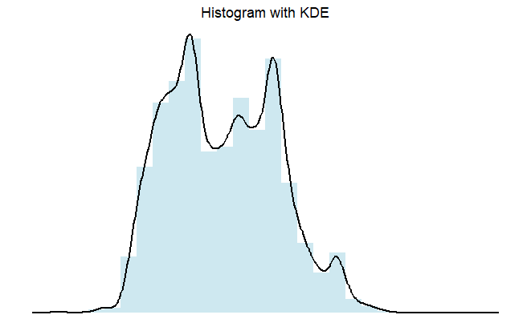

```r
# Convert KDE to data frame
kde_df <- data.frame(x = kde$x, y = kde$y)

#load package
library(ggplot2)

# Histogram + KDE overlay
ggplot(data.frame(x = x), aes(x = x)) +
  geom_histogram(aes(y = ..density..), bins = 30, fill = "lightblue", color = NA, alpha = 0.6) +
  geom_line(data = kde_df, aes(x = x, y = y), color = "black", size = 1) +
  ggtitle("Histogram with KDE") +
  theme_void() +
  theme(plot.title = element_text(hjust = 0.5))
```

### Conclusion

Using maximum likelihood estimation and three information criteria (AIC, SBC, and ICOMP), we compared the fit of several candidate probability density functions (Normal, Lognormal, Weibull, Gamma, and Inverse-Gaussian) to the stream temperature dataset. Among the parametric models, the Inverse-Gaussian distribution achieved the lowest IC values, suggesting it was the best-fitting parametric PDF. However, when compared with the nonparametric Gaussian Kernel Density Estimation (KDE), the KDE achieved even lower IC values.

This result is consistent with the visual inspection of the data’s histogram, which displayed a bimodal structure. Parametric distributions, including the Inverse-Gaussian, assume unimodality and therefore cannot fully capture the complexity of the observed distribution. In contrast, the KDE adapts more flexibly to the shape of the data, capturing the bimodal pattern and providing a better balance between model complexity and fit.

The implication is that while the Inverse-Gaussian provides a reasonable parametric approximation of the stream temperature distribution, nonparametric approaches like KDE may be more appropriate when the data exhibit multimodality. This highlights the importance of considering both parametric and nonparametric models in environmental data analysis, particularly when the underlying processes produce complex, multimodal distributions.